# ECOM30004/90004 Time Series Analysis and Forecasting Tutorial 9 Tutor: Pengyun (Kevin) Chen University of Melbourne Semester 2, 2026

## Notice

**Conditions of Use**

- This document is intended for personal use and is NOT meant to be shared on the internet (e.g. Studocu, ThinkSwap, StudentVIP, Coursehero, etc.)
- Do not share this document with anyone, even if they are enrolled in ECOM30004/90004.
- Official course materials, such as lecture slides, tutorial sheets and prescribed readings should always be your primary point of reference.
- Slides accessible here: `pengyunc.github.io/TSAF_Week9`
- Download HTML versions here: [Dropbox Link](https://www.dropbox.com/scl/fo/aoxoud5ex0j42hsrod3dg/ADblAt_jJ9hpESZME9FDcWc?rlkey=0s0oyf1y3uokzvlhbzxe2yy3g&st=kx2yupzr&dl=0)

## This tutorial

This tutorial uses lag polynomials to (A) understand and (B) extend our ARMA modelling approach.

**Agenda**

- We will make use of `BAB3mth.csv` from Week 4 and `RetailSales.csv` from Week 1.
- All code is provided in the questions in order to focus on the concepts and results.
- Part A: Common factors in ARMA models (`BAB3mth.csv`)
- Part B: Multiplicative models: seasonal autoregression (`RetailSales.csv`)

**Initialisation** for Part A

```r
library(urca)
library(forecast)

dt <- read.csv("BAB3mth.csv")
Y <- ts(dt$BAB3, start=c(2010,1), end=c(2025,6), frequency=12)
DY <- diff(Y)
Y <- window(Y, end=c(2024,6))
DY <- window(DY, end=c(2024,6))
```

## Recap - What’s going on?

Estimating an AR model is computationally simple.

- you can simply compute this by OLS (by matrix algebra, $\hat{\beta}=(X^{\top}X)^{-1}(X^{\top}y)$)

Estimating a model with an MA component is much more computationally intensive.

- you need to rely on numerical methods (e.g. maximum likelihood)

Suppose we want to estimate the most basic ARMA(1,1).
$$y_{t}=\phi_{1}y_{t-1}+U_{t}+\theta_{1}U_{t-1}$$
The maximum likelihood algorithm proceeds as follows:

- First, guess $(\phi_{1},\theta_{1})$.
- Next, plug these values into the model, and compute the implied residuals $U_{t}$.
- Compute the likelihood function (how probable the observed data are given those parameters)
- Repeat the process until the likelihood function is maximised.

However, with invertibility, the MA component can be approximated by AR models.

## What’s going on?

However, with invertibility, the MA component can be approximated by AR models.

**What is invertibility?**

MA is invertible $\to$ can be re-written as an AR($\infty$) representation (with converging coefficients)

**Why can AR models approximate the MA component?**

**Lecture Example: MA(1)**

$$\begin{aligned}
Z_{t}=U_{t}+\theta_{1}U_{t-1}\;\;\xrightarrow{\textsf{can be written as}}\;\;& Z_{t}=\sum^{\infty}_{j=1}-(-\theta_{1})^{j}Z_{t-j}+U_{t}\\
\textsf{or, when there is finite horizon:}\;\;& Z_{t}=\sum^{t-1}_{j=1}-(-\theta_{1})^{j}Z_{t-j}+U_{t}-(-\theta_{1})^{t}U_{0}
\end{aligned}$$

If $|\theta_{1}|<1$, then $(-\theta_{1})^{t}$ shrinks to 0 as $t$ becomes larger $\to$ ignoring certain higher-order AR terms can still yield a reasonable approximation.

## What makes an MA model invertible?

**Example:** In Tutorial 8, the optimal ARMA model for $\Delta Y_{t}$ is ARMA(1,2) with drift.
$$\begin{align*}
\Delta{}Y_{t}&=\beta_{0}+Z_{t}\\
Z_{t}&=\phi_{1}Z_{t-1}+U_{t}+\theta_{1}U_{t-1}+\theta_{2}U_{t-2}
\end{align*}$$

Consider only the second equation. Moving all AR terms to the LHS gives:
$$Z_{t}-\phi_{1}Z_{t-1}=U_{t}+\theta_{1}U_{t-1}+\theta_{2}U_{t-2}$$

Next, replace the notation with lag operators $L$, where $L^{n}(x_{t})=x_{t-n}$:

$$Z_{t}-\phi_{1}L(Z_{t})=U_{t}+\theta_{1}L(U_{t})+\theta_{2}L^{2}(U_{t})$$

$$(1-\phi_{1}L)Z_{t}=\color{green}{\underbrace{(1+\theta_{1}L+\theta_{2}L^{2})}_{\substack{\textsf{the MA lag polynomial}\\\textsf{we are interested in}}}}\color{black}{U_{t}}$$

Compute the solution of the lag polynomial for the MA component:

$$\begin{align*}
1+\theta_{1}z+\theta_{2}z^{2}&=0\\
\color{teal}{\boxed{\textsf{\small{}Suppose the solutions are $\to$}}}\qquad \zeta_{1},\zeta_{2}&=\frac{-\theta_{1}\pm\sqrt{\theta_{1}^{2}-4\theta_{2}}}{2\theta_{2}}
\end{align*}$$

## What makes an MA model invertible?

Compute the solution of the lag polynomial for the MA component:

$$\begin{align*}
1+\theta_{1}z+\theta_{2}z^{2}&=0\\
\color{teal}{\boxed{\textsf{\small{}Suppose the solutions are $\to$}}}\qquad \zeta_{1},\zeta_{2}&=\frac{-\theta_{1}\pm\sqrt{\theta_{1}^{2}-4\theta_{2}}}{2\theta_{2}}
\end{align*}$$

This means that the lag polynomial can be rewritten as:

$$(\zeta_{1}-z)(\zeta_{2}-z)=0$$

$$\color{teal}{\zeta_{1}}\color{black}{(1-\zeta_{1}^{-1}z)\,\times\,} \color{teal}{\zeta_{2}}\color{black}{(1-\zeta_{2}^{-1}z)=0}$$

$$(1-\zeta_{1}^{-1}z)(1-\zeta_{2}^{-1}z)=0$$

The MA component is **invertible** if:
$$|\zeta_{1}^{-1}|<1\quad \text{and}\quad |\zeta_{2}^{-1}|<1.$$
Graphically, the inverse roots of the MA lag polynomial should lie **within** the unit circle in the Real-Imaginary plane.

## What makes an MA model invertible?

The MA component is **invertible** if:
$$|\zeta_{1}^{-1}|<1\quad \text{and}\quad |\zeta_{2}^{-1}|<1.$$
Graphically, the inverse roots of the MA lag polynomial should lie **within** the unit circle in the Real-Imaginary plane.

**Aside.** Consider an ARMA(2,2) model:
$$\begin{align*}
(1-\phi_{1}L-\phi_{2}L^{2})Z_{t}&=(1+\theta_{1}L+\theta_{2}L^{2})U_{t}\\
(1-\xi_{1}^{-1}L)(1-\xi_{2}^{-1}L)Z_{t}&=(1-\zeta_{1}^{-1}L)(1-\zeta_{2}^{-1}L)U_{t}
\end{align*}$$
where $\xi_{1}^{-1},\xi_{2}^{-1}$ are inverse roots of the AR lag polynomial: $1-\phi_{1}z-\phi_{2}z^{2}=0$.

The AR component is **stationary** if:
$$|\xi_{1}^{-1}|<1\quad\text{and}\quad |\xi_{2}^{-1}|<1$$
Graphically, the inverse roots of the AR lag polynomial should lie **within** the unit circle in the Real-Imaginary plane.

## What makes an MA model invertible?

The MA component is **invertible** if:
$$|\zeta_{1}^{-1}|<1\quad \text{and}\quad |\zeta_{2}^{-1}|<1.$$
Graphically, the inverse roots of the MA lag polynomial should lie **within** the unit circle in the Real-Imaginary plane.

- Parameter Estimates
- MA Inverse Roots
- Checking Magnitude
- Plot

```r
eq <- Arima(DY, order=c(1,0,2))       # ARMA(1,2)
print(coef(eq))
```

```
         ar1          ma1          ma2    intercept
 0.903845857 -0.304583703 -0.310499904  0.004002802
```

Thus the lag polynomial for the MA component is:
$$\begin{align*}
1+\theta_{1}z+\theta_{2}z^{2}&=0\\
1-0.3046z-0.3105z^{2}&=0
\end{align*}$$

The `polyroot()` function in R solves for the complex roots of a polynomial.

(the coefficients has to be ordered from the constant term to the highest degree term)
$$1+\theta_{1}z+\theta_{2}z^{2}=0$$

```r
MA2roots <- polyroot(c(1,eq$coef[c("ma1", "ma2")]))
MA2invroots <- 1/MA2roots
print(round(MA2invroots,4))
```

```
[1]  0.7300+0i -0.4254+0i
```

So we have $\zeta_{1}^{-1}=0.7300$ and $\zeta_{2}^{-1}=-0.4254$.

The magnitudes for these inverse roots (takes form $\zeta^{-1}=a+ib$) are:

$$|\zeta^{-1}|=\sqrt{a^{2}+b^{2}} \quad\implies\quad\begin{aligned}|\zeta_{1}^{-1}|&=\sqrt{0.73^{2}+0^{2}}=0.73\;\color{green}{<1}\\
|\zeta_{2}^{-1}|&=\sqrt{(-0.4254)^{2}+0^{2}}=0.4254\;\color{green}{<1}
\end{aligned}$$

The relevant R function is `Mod()`:

```r
print(Mod(MA2invroots))
```

```
[1] 0.7299533 0.4253696
```

Since both inverse roots are less than 1 in magnitude $\to$ lies within the unit circle.

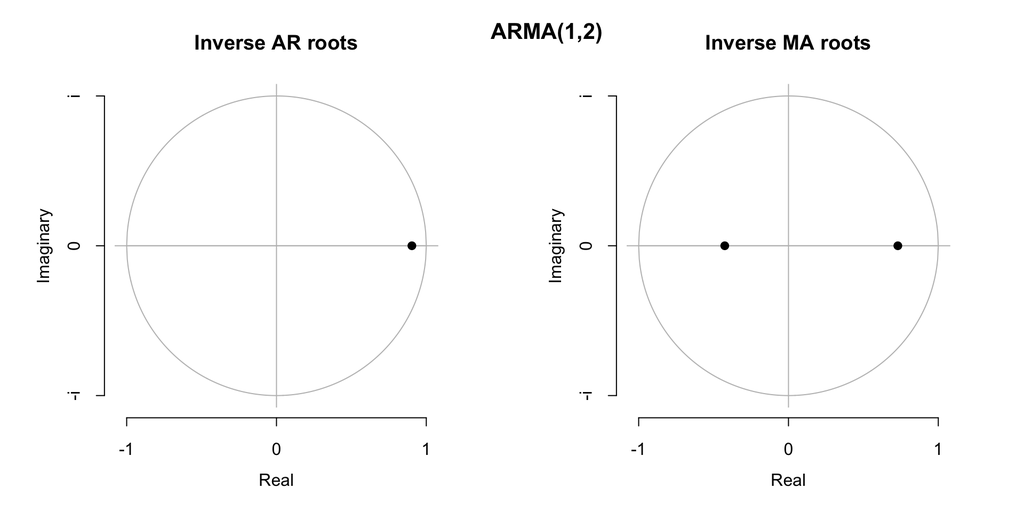

```r
plot(eq)
mtext(paste0("ARMA(",1,",",2,")  "),
side=3, line=2, cex=1.3, font=2)
```

$$\begin{aligned}
&\textsf{Right panel:}\\
&\zeta_{1}^{-1}=0.7300\\
&\zeta_{2}^{-1}=-0.4254
\end{aligned}$$

## Part A - Exercise 1: Common factors in ARMA models

Progressively increment the orders of *both* AR and MA models so that we estimate ARMA(1,2), ARMA(2,3), ARMA(3,4) and ARMA(4,5) models.

Plot the inverted roots for these four models. Discuss the implication of plots.

```r
for (j in 0:3){
  eq <- Arima(DY, order=c(1+j,0,2+j))
  plot(eq)
  mtext(paste0("ARMA(",1+j,",",2+j,")"),
    side=3, line=2, cex=1.3, font=2) }
```

- ARMA(1,2)
- ARMA(2,3)
- ARMA(3,4)
- ARMA(4,5)

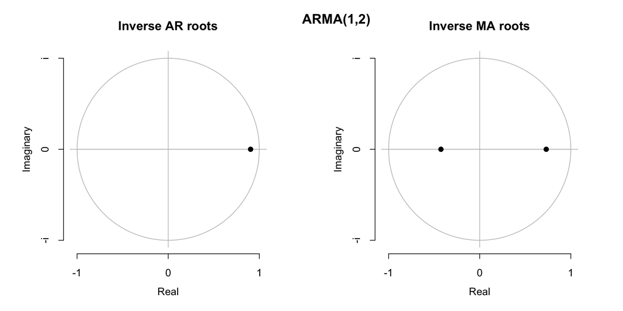

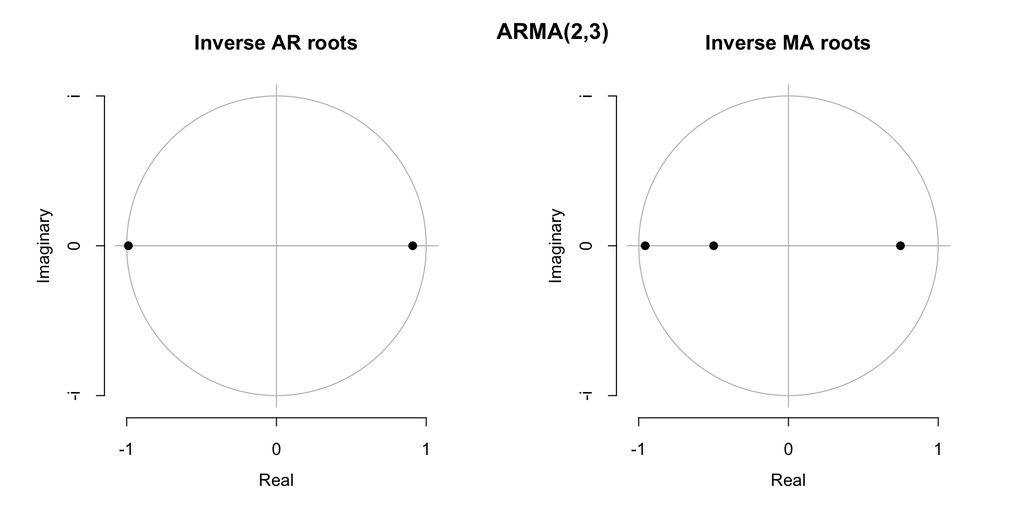

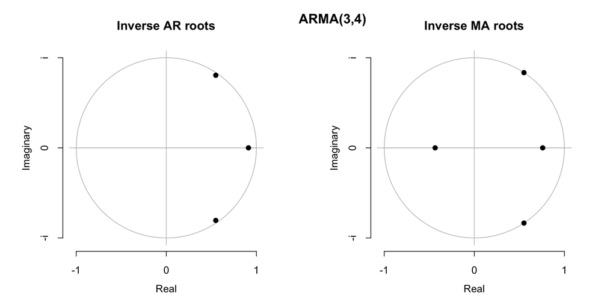

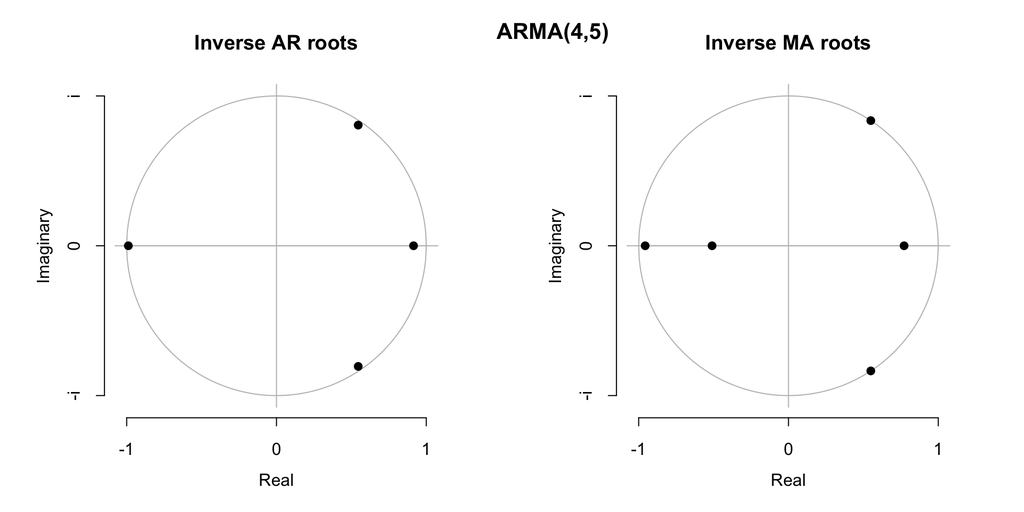

## Part A - Exercise 1: Common factors in ARMA models

- ARMA(1,2)
- ARMA(2,3)
- ARMA(3,4)
- ARMA(4,5)

```r
eq <- Arima(DY, order=c(1,0,2))
MA2invroots <- 1/polyroot(c(1,eq$coef[c("ma1", "ma2")]))
print(round(MA2invroots,4))         # MA Inverse roots
```

```
[1]  0.7300+0i -0.4254+0i
```

```r
print(round(Mod(MA2invroots),4))    # Magnitudes of MA inverse roots
```

```
[1] 0.7300 0.4254
```

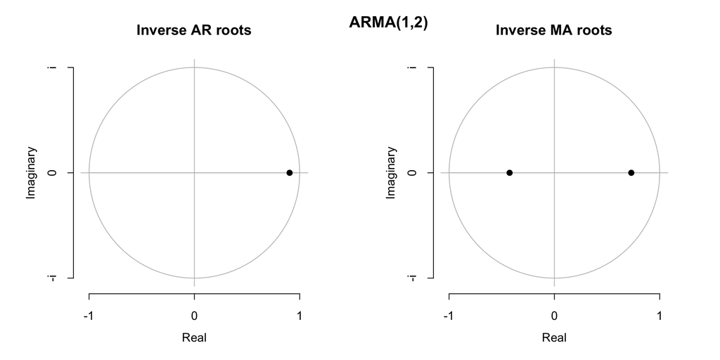

```r
eq <- Arima(DY, order=c(2,0,3))
MA3invroots <- 1/polyroot(c(1,eq$coef[c("ma1", "ma2", "ma3")]))
print(round(MA3invroots,4))         # MA Inverse roots
```

```
[1]  0.7477+0i -0.9564+0i -0.4993+0i
```

```r
print(round(Mod(MA3invroots),4))    # Magnitudes of MA inverse roots
```

```
[1] 0.7477 0.9564 0.4993
```

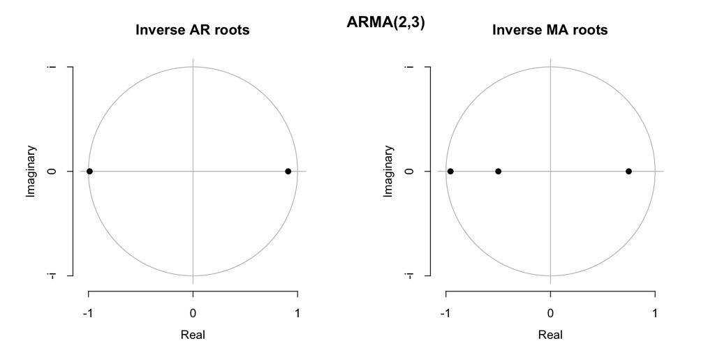

Both extra inverted AR and MA roots are very close to 1

$\Rightarrow$ this model for the same time series apparently has suddenly become both non-stationary and non-invertible.

$\swarrow$

$\swarrow$

```r
eq <- Arima(DY, order=c(3,0,4))
MA4invroots <- 1/polyroot(c(1,eq$coef[c("ma1", "ma2", "ma3", "ma4")]))
print(round(MA4invroots,4))         # MA inverse roots
```

```
[1]  0.5508-0.8347i  0.5508+0.8347i  0.7586+0.0000i -0.4346+0.0000i
```

```r
print(round(Mod(MA4invroots),4))    # Magnitudes of MA inverse roots
```

```
[1] 1.0000 1.0000 0.7586 0.4346
```

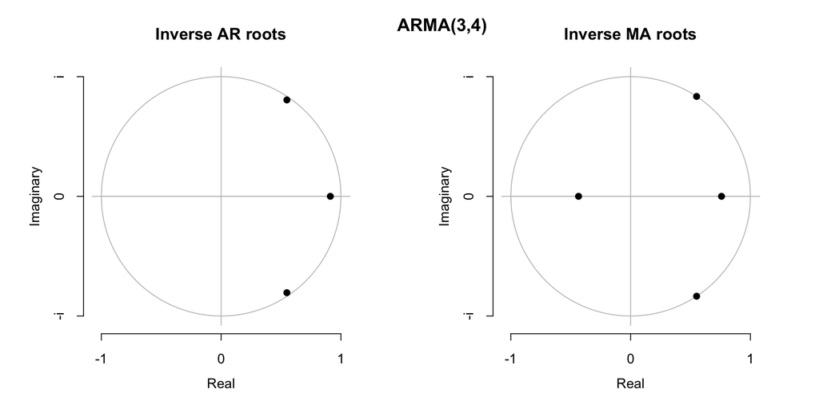

With the addition of 2 to both AR and MA orders, we now have two additional (very close to) non-stationary AR inverse roots and two non-invertible MA inverse roots, all four of which happen to be complex.

$\nearrow$

$\searrow$

$\nearrow$

$\searrow$

```r
eq <- Arima(DY, order=c(4,0,5))
MA5invroots <- 1/polyroot(c(1,eq$coef[c("ma1", "ma2", "ma3", "ma4", "ma5")]))
print(round(MA5invroots,4))         # MA inverse roots
```

```
[1]  0.5496-0.8354i -0.9563+0.0000i  0.5496+0.8354i  0.7717+0.0000i
[5] -0.5101+0.0000i
```

```r
print(round(Mod(MA5invroots),4))    # Magnitudes of MA inverse roots
```

```
[1] 1.0000 0.9563 1.0000 0.7717 0.5101
```

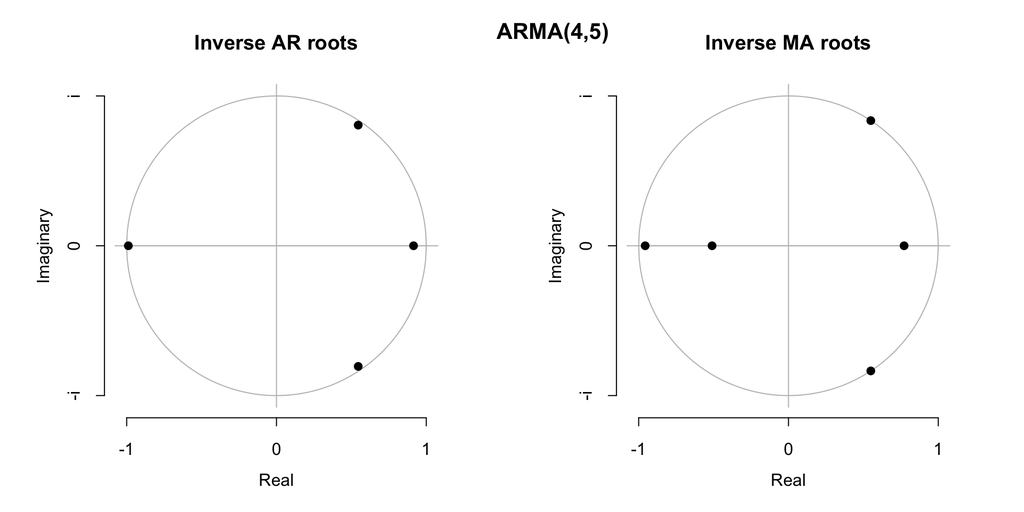

Now there are three additional (very close to) non-stationary AR inverse roots and non-invertible MA inverse roots.

$\nearrow$

$\searrow$

$\nearrow$

$\searrow$

$\swarrow$

$\swarrow$

## Part A - Exercise 1: Common factors in ARMA models

**What is going on here?**

In Tutorial 8, the optimal ARMA model for $\Delta Y_{t}$, chosen by the AICc, is ARMA(1,2). Let’s assume that it is the correct model.

The AIC-selected ARMA(1,2) model can be written symbolically as:

$$(1-\xi_{1}^{-1}L)Z_{t}=(1-\zeta_{1}^{-1}L)(1-\zeta_{2}^{-1}L)U_{t}$$

The AR and MA inverse roots are:

```
      xi_1  zeta_1     zeta_2
 0.9038+0i 0.73+0i -0.4254+0i
```

$$(1-0.9038L)Z_{t}=(1-0.73L)(1+0.4254L)U_{t}$$

If ARMA(1,2) is indeed the correct model, then if we increment the specification to ARMA(2,3),
$$(1-\xi_{1}^{-1}L)(1-\color{purple}{\xi_{2}^{-1}}\color{black}{L)Z_{t}=(1-\zeta_{1}^{-1}L)(1-\zeta_{2}^{-1}L)(1\,-}\color{teal}{\,\zeta_{3}^{-1}}\color{black}{L)U_{t}}$$
the “correct” values of the excess terms $\xi_{2}^{-1}$ and $\zeta_{3}^{-1}$ should be 0.

## Part A - Exercise 1: Common factors in ARMA models

**What is going on here?**

$$(1-0.9038L)Z_{t}=(1-0.73L)(1+0.4254L)U_{t}$$

If ARMA(1,2) is indeed the correct model, then if we increment the specification to ARMA(2,3),
$$(1-\xi_{1}^{-1}L)(1-\color{purple}{\xi_{2}^{-1}}\color{black}{L)Z_{t}=(1-\zeta_{1}^{-1}L)(1-\zeta_{2}^{-1}L)(1\,-}\color{teal}{\,\zeta_{3}^{-1}}\color{black}{L)U_{t}}$$
the “correct” values of the excess terms $\xi_{2}^{-1}$ and $\zeta_{3}^{-1}$ should be 0.

Unfortunately things get more complicated in this specification.

The AR and MA inverse roots for ARMA(2,3) are:

```
      xi_1       xi_2    zeta_1     zeta_2     zeta_3
 0.9092+0i -0.9885+0i 0.7477+0i -0.9564+0i -0.4993+0i
```

$$(1-0.9092L)(1-\color{purple}{(-0.9885)}\color{black}{L)Z_{t}=(1-0.7477L)(1+0.4993L)(1-}\color{teal}{(-0.9564)}\color{black}{L)U_{t}}$$

where $\xi_{2}^{-1}=-0.9885$ and $\zeta_{3}^{-1}=-0.9564$ are very much not 0.

## Part A - Exercise 1: Common factors in ARMA models

**What is going on here?**

$$(1-0.9038L)Z_{t}=(1-0.73L)(1+0.4254L)U_{t}$$

$$(1-0.9092L)\color{red}{(1+0.9885L)}\color{black}{Z_{t}=(1-0.7477L)(1+0.4993L)}\color{red}{(1+0.9564L)}\color{black}{U_{t}}$$

By introducing the extra terms on both sides we have introduced what is referred to as a “common factor”, and the “common factor” can be “cancelled” from both sides.

What does this mean, and what is the problem?

- There is only one true data generating process in reality, indicating there is a unique set of AR and MA roots $(\xi_{1}^{-1},\xi_{2}^{-1},\zeta_{1}^{-1},\zeta_{2}^{-1},\zeta^{-1}_{3})$. Therefore, there should only be a unique set of AR $(\phi_{1},\phi_{2})$ and MA $(\theta_{1},\theta_{2},\theta_{3})$ parameters.
- Since the common factor can be cancelled out, the inverse roots $\xi_{2}^{-1}$ and $\zeta_{3}^{-1}$ can now take on a range of values **as long as $\xi_{2}^{-1}=\zeta_{3}^{-1}$**. $\implies$ the model parameters $(\phi_{1},\phi_{2},\theta_{1},\theta_{2},\theta_{3})$ are NOT unique $\implies$ the model is **NOT identified!**
- This is why the numerical algorithm pushes the excess parameters ($\xi_{2}^{-1}$, $\zeta_{3}^{-1}$) towards the unit circle, even though we might expect them to shrink towards zero.

## Part A - Exercise 1: Common factors in ARMA models

**Some practical observations:**

- If an ARMA($p,q$) model has inverse roots that nearly cancel, especially near the unit circle, you should reconsider whether smaller orders would suffice.
- As AIC/AICc is balancing between model complexity and fit quality, it would usually be the case that it will work to avoid this issue.
  - However, it is worth acknowledging that AICc is not perfect and might select models that is too large.
- When doing model selection searches, it is generally advised to avoid increasing the order of both AR and MA components simultaneously.
  - It is better to increase AR or MA components separately, in which case this potential identification problem should be avoided.
  - Brute-force AIC search over ($p,q$) works for small grids but can cause instability at larger orders $\to$ there exists smarter methods (e.g. `auto.arima`) avoid this.
- More pragmatically, at least in economics and finance it has become more common to rely simply on AR models rather than ARMA.
  - Avoids the common factor problem, quicker (can use OLS), more stable than ARMA, and simplifies extensions to multivariate models (e.g. VAR).

## Part B: Multiplicative Models: Seasonal Autoregression

An alternative model for seasonality is the seasonal AR model. (There is also a seasonal MA model, which follows the same principles.)

A simple example is the first order seasonal AR (SAR) model, specified here for quarterly data:

$$Z_{t}=\Phi_{1}Z_{t-4}+U_{t}\quad \iff\quad (1-\Phi_{1}L^{4})Z_{t}=U_{t}$$

That is, $Y_{t}$ is modeled directly in terms of the observation from one year ago. This is four time periods for quarterly data, hence the $Z_{t-4}$ term.

In general we can have higher order seasonal AR models:
$$(1-\Phi_{1}L^{4}-\cdots-\Phi_{P}L^{4P})Z_{t}=U_{t}$$

which expresses the forecasts for $Y_{t}$ in terms of observations from $1,\dots,P$ years ago.

## Part B: Multiplicative Models: Seasonal Autoregression

Most commonly the SAR model is combined with an AR model, so that seasonal and non-seasonal components are permitted.

This is done in a multiplicative manner using lag polynomials.

For example an AR(1),SAR(1) model is
$$(1-\phi_{1}L)(1-\Phi_{1}L^{4})Z_{t}=U_{t}$$
This is essentially a restricted AR(5) model. $\to$ Exercise 2(a)

In general an AR($p$),SAR($P$) model is
$$(1-\phi_{1}L-\cdots-\phi_{p}L^{p})(1-\Phi_{1}L^{4}-\cdots-\Phi_{P}L^{4P})Z_{t}=U_{t}$$
The selection of $p$ and $P$ can be handled in the usual way using AIC and residual autcorrelation checks with Ljung-Box testing.

## Exercise 2(a)

Expand the lag polynomials in the AR(1),SAR(1) model to show that it is equivalent to an AR(5) model with particular parameter restrictions.
$$(1-\phi_{1}L)(1-\Phi_{1}L^{4})Z_{t}=U_{t}$$

We can algebraically manipulate lag polynomials like any other polynomial:

$$\begin{align}
(1-\phi_{1}L)(1-\Phi_{1}L^{4})&=1-\phi_{1}-\Phi_{1}L^{4}+\phi_{1}\Phi_{1}L\cdot L^{4}\\
&=1-\phi_{1}-\Phi_{1}L^{4}+\phi_{1}\Phi_{1}L^{5}
\end{align}$$

Thus the model can be re-written as:

$$(1-\phi_{1}L-\Phi_{1}L^{4}+\phi_{1}\Phi_{1}L^{5})Z_{t}=U_{t}$$

$$\implies\qquad Z_{t}=\phi_{1}Z_{t-1}+\Phi_{1}Z_{t-4}-\phi_{1}\Phi_{1}Z_{t-5}+U_{t}$$

Comparing this model with the standard AR(5) setup:
$$Z_{t}=\phi_{1}^* Z_{t-1}+\phi_{2}^* Z_{t-2}+\phi_{3}^* Z_{t-3}+\phi_{4}^* Z_{t-4}+\phi_{5}^* Z_{t-5}+U_{t}$$

the restrictions are $\phi_{1}^*=\phi_{1}$, $\phi_{2}=\phi_{3}=0$, $\phi_{4}^{*}=\Phi_{1}$ and $\phi_{5}^*=-\phi_{1}\Phi_{1}$.

## Exercise 2(b)

Using `RetailSales.csv` from Week 1/2, carry out a model selection search over AR($p$), SAR($P$) models with maximum of 4 for both $p$ and $P$.

$$(1-\phi_{1}L-\cdots-\phi_{p}L^{p})(1-\Phi_{1}L^{4}-\cdots-\Phi_{P}L^{4P})Z_{t}=U_{t}$$
What is the longest lag of $Z_{t}$ implied by this AR,SAR model?

**Initialisation:** Copy the following to set up in the usual way

```r
library(forecast)

# Set up log retail sales, 2000q1 to 2019q4
dt <- read.csv("RetailSales.csv")
Retail_m <- ts(dt$Total, frequency=12, start=c(1982,4), end=c(2024,9))
Retail_q <- aggregate(Retail_m, nfrequency=4)
log_Retail_q <- log(Retail_q)
Y <- window(log_Retail_q, start=c(2000,1), end=c(2019,4))

# Linear trend
Time <- time(Y)
```

(continued next slide…)

## Exercise 2(b)

Set up deterministics:

```r
# GFC trend break
gfc <- 2008.5
Time_postgfc <- 1*(Time>gfc)*(Time-gfc)

# Quarterly dummies
QD <- seasonaldummy(Y)

# Deterministics without seasonal dummies
X <- cbind(Time, Time_postgfc)

# Deterministics with seasonal dummies
XQD <- cbind(Time, Time_postgfc, QD)
```

Define samples for estimation and forecast evaluation:

```r
# Estimation sample
t_est <- which(Time<2019)
Y <- window(log_Retail_q, start=c(2000,1), end=c(2018,4))

# Forecast evaluation sample
t_for <- which(Time>=2019)
Yf <- window(log_Retail_q, start=c(2019,1), end=c(2019,4))
```

## Exercise 2(b)

Using `RetailSales.csv` from Week 1/2, carry out a model selection search over AR($p$), SAR($P$) models with maximum of 4 for both $p$ and $P$.

$$(1-\phi_{1}L-\cdots-\phi_{p}L^{p})(1-\Phi_{1}L^{4}-\cdots-\Phi_{P}L^{4P})Z_{t}=U_{t}$$
What is the longest lag of $Z_{t}$ implied by this AR,SAR model?

```r
pmax <- 4
Pmax <- 4
AICc <- matrix(nrow=1+pmax, ncol=1+Pmax)
rownames(AICc) <- paste0("AR",0:pmax)
colnames(AICc) <- paste0("SAR",0:Pmax)
LBp <- AICc

for (p in 0:pmax){
  for (P in 0:Pmax){

    # Specification of AR(p), SAR(P) model:
    eq_sar <- Arima(Y, order=c(p,0,0), xreg=X[t_est,],
            seasonal=list(order=c(P,0,0), period=4))

    AICc[1+p,1+P] <- eq_sar$aicc
    LBp[1+p,1+P] <- Box.test(eq_sar$residuals, type="Ljung-Box",
                                fitdf=p+P, lag=12)$p.value
  }
}
```

## Exercise 2(b)

Using `RetailSales.csv` from Week 1/2, carry out a model selection search over AR($p$), SAR($P$) models with maximum of 4 for both $p$ and $P$.

$$(1-\phi_{1}L-\cdots-\phi_{p}L^{p})(1-\Phi_{1}L^{4}-\cdots-\Phi_{P}L^{4P})Z_{t}=U_{t}$$
What is the longest lag of $Z_{t}$ implied by this AR,SAR model?

**Results:**

- AICc values
- Model selection search
- Residual autocorrelation

```r
print(round(AICc, 4))
```

```
         SAR0      SAR1      SAR2      SAR3      SAR4
AR0 -183.9288 -383.6143 -393.7658 -382.5243 -380.7893
AR1 -186.8830 -427.5469 -436.8123 -440.0512 -437.5669
AR2 -197.8278 -427.5613 -434.8512 -437.7967 -435.1855
AR3 -243.8547 -430.7242 -434.3403 -436.3189 -433.6872
AR4 -379.5825 -379.1405 -432.4139 -376.3585 -431.2748
```

```r
print(AICc==min(AICc))
```

```
     SAR0  SAR1  SAR2  SAR3  SAR4
AR0 FALSE FALSE FALSE FALSE FALSE
AR1 FALSE FALSE FALSE  TRUE FALSE
AR2 FALSE FALSE FALSE FALSE FALSE
AR3 FALSE FALSE FALSE FALSE FALSE
AR4 FALSE FALSE FALSE FALSE FALSE
```

The selected model has $p=1$ and $P=3$. $\implies$ longest lag of $Z_{t}$ is 13.

$$\color{teal}{\boxed{\textsf{\small\;found by expanding this }\to\;}}\quad\color{black}{ (1-\phi_{1}L)(1-\Phi_{1}L^{4}-\Phi_{2}L^{8}-\Phi_{3}L^{12})Z_{t}=U_{t}}$$

```r
print(round(LBp,3))
```

```
    SAR0  SAR1  SAR2  SAR3  SAR4
AR0    0 0.000 0.000 0.000 0.000
AR1    0 0.079 0.512 0.739 0.693
AR2    0 0.086 0.433 0.711 0.634
AR3    0 0.346 0.472 0.485 0.425
AR4    0 0.000 0.402 0.000 0.426
```

```r
print(1*(LBp<0.05))
```

```
    SAR0 SAR1 SAR2 SAR3 SAR4
AR0    1    1    1    1    1
AR1    1    0    0    0    0
AR2    1    0    0    0    0
AR3    1    0    0    0    0
AR4    1    1    0    1    0
```

Since $p=0.739>0.05$, we can maintain $H_0$ of no residual autocorrelation

$\implies$ the AR(1),SAR(3) model is not misspecified.

## Exercise 2(b)

Use the a model with the selected $p$ and $q$ to forecast the four quarters of 2019 (i.e. 1,2,3,4-steps ahead), and compute their RMSE.

```r
p <- 1
P <- 3
eq_sar <- Arima(Y, order=c(p,0,0), xreg=X[t_est,],
        seasonal=list(order=c(P,0,0), period=4))

# Forecast through 2019
Yf_sar <- forecast(eq_sar, xreg=X[t_for,])$mean

# Compute RMSE
RMSE_sar <- sqrt(mean((Yf-Yf_sar)^2))
```

The forecasts from AR(1),SAR(3) are:

```r
print(Yf_sar)
```

```
         Qtr1     Qtr2     Qtr3     Qtr4
2019 11.26355 11.28073 11.30355 11.44880
```

The RMSE for AR(1),SAR(3) forecasts is:

```r
print(RMSE_sar)
```

```
[1] 0.00788378
```

## Exercise 2(c)

Previously we have identifed an AR(3) model is suitable when also using a linear trend with GFC break and quarterly dummies. Estimate this model, obtain the forecasts for the four quarters of 2019, and compute their RMSE.

```r
# Estimation of AR(3) with XQD as deterministic matrix (with seasonal dummies)
eq_qd <- Arima(Y, order=c(3,0,0), xreg=XQD[t_est,])

# Forecast through 2019
Yf_qd <- forecast(eq_qd, xreg=XQD[t_for,])$mean

# Compute RMSE
RMSE_qd <- sqrt(mean((Yf-Yf_qd)^2))
```

The forecasts from AR(3) are:

```r
print(Yf_qd)
```

```
         Qtr1     Qtr2     Qtr3     Qtr4
2019 11.25779 11.27883 11.30279 11.45205
```

The RMSE for AR(3) forecasts is:

```r
print(RMSE_qd)
```

```
[1] 0.00804294
```

$\longleftarrow$ The SAR model has slightly lower RMSE (at 0.0078) than the AR(3) with quarterly dummies.

## Exercise 2(d)

Repeat the search in (b) but with quarterly dummies also included. This is combining both quarterly dummies and seasonal AR modelling to capture the seasonality in the data.

First, observe the AICc values:

```r
# AICc for AR(3) with seasonal dummies
print(eq_qd$aicc)
```

```
[1] -472.9557
```

```r
# AICc for Seasonal AR: AR(1),SAR(3)
print(eq_sar$aicc)
```

```
[1] -440.0512
```

The model with quarterly dummies is clearly preferred by the AICc to the seasonal autoregression.

## Exercise 2(d)

Repeat the search in (b) but with quarterly dummies also included. This is combining both quarterly dummies and seasonal AR modelling to capture the seasonality in the data.

We would like to check if including the quarterly dummies in the seasonal AR model may improve the model further: (conduct the grid search again, but use `XQD` instead)

```r
pmax <- 4
Pmax <- 4
AICc <- matrix(nrow=1+pmax, ncol=1+Pmax)
rownames(AICc) <- paste0("AR",0:pmax)
colnames(AICc) <- paste0("SAR",0:Pmax)
LBp <- AICc

for (p in 0:pmax){
  for (P in 0:Pmax){
    eq_sar <- Arima(Y, order=c(p,0,0), xreg=XQD[t_est,],  # <-- changed
          seasonal=list(order=c(P,0,0), period=4))
    AICc[1+p,1+P] <- eq_sar$aicc
  }
}
```

## Exercise 2(d)

Repeat the search in (b) but with quarterly dummies also included. This is combining both quarterly dummies and seasonal AR modelling to capture the seasonality in the data.

We would like to check if including the quarterly dummies in the seasonal AR model may improve the model further: (conduct the grid search again, but use `XQD` instead)

Thus when quarterly dummies are used…

```r
print(AICc==min(AICc))
```

```
     SAR0  SAR1  SAR2  SAR3  SAR4
AR0 FALSE FALSE FALSE FALSE FALSE
AR1 FALSE FALSE FALSE FALSE FALSE
AR2 FALSE FALSE FALSE FALSE FALSE
AR3  TRUE FALSE FALSE FALSE FALSE
AR4 FALSE FALSE FALSE FALSE FALSE
```

… AR(3) remains the preferred specification $\to$ there is no further improvement in model fit by also using seasonal autoregressive components.

Thank you for coming!